# CE50 et CE10 sur daphnies : régression logistique

Dichromate de potassium (G1) et diclofénac (G4, G6)

# 1 Objectif et démarche

On cherche, pour chaque jeu de données, la concentration qui tue 50 % (**CE50**) et 10 % (**CE10**) des daphnies, à partir d’une courbe dose-réponse ajustée par régression logistique.

**Les données.** Chaque ligne du CSV est une concentration, chaque colonne `replicat k` un réplicat, et la valeur est un *taux de survie en %*. Tous les taux sont des multiples de 20 %, donc chaque réplicat contient **5 daphnies** (hypothèse vérifiée dans le code). On reconstruit donc, pour chaque réplicat, le nombre de daphnies mortes sur 5.

**Pourquoi une régression logistique (et pas `nls` comme dans `MNL.Rmd`).** La variable étudiée est un *nombre de morts sur 5*, donc une loi binomiale, pas une variable gaussienne. On utilise donc, comme dans `modèle_logistique.rmd`, un `glm` binomial avec lien logit, plutôt que `nls` qui suppose des erreurs gaussiennes de variance constante.

**Deux modèles comparés :**

| Modèle | Formule de la probabilité de mort | Définition de la CEx |
| --- | --- | --- |
| **M1** (modèle du TD) | $p = \mathrm{logit}^{-1}(\beta_0+\beta_1\,\text{conc})$ | concentration où la mortalité *totale* vaut x % |
| **M2** (pratique en écotoxicologie) | $p = c + (1-c)\,\mathrm{logit}^{-1}(\beta_0+\beta_1\ln \text{conc})$, avec $c$ = mortalité du témoin | concentration provoquant x % de mortalité *en plus* du témoin (correction d’Abbott) |

M2 est ajouté parce que les témoins de G1 et G4 ont ~10 % de mortalité : sans correction, la CE10 de M1 est presque confondue avec la mortalité naturelle. M2 utilise aussi le logarithme de la concentration, qui est l’échelle habituelle des courbes dose-réponse (le témoin à 0 est traité à part : $p=c$).

**Hypothèses vérifiées pour M1** (plusieurs tests proposés pour chacune) :

| # | Hypothèse | Tests utilisés |
| --- | --- | --- |
| H0 | La concentration a un effet | Test du rapport de vraisemblance (LRT) contre le modèle nul + test de Wald |
| H1 | Indépendance des observations | Non testable statistiquement : relève du plan d’expérience (voir remarque) |
| H2 | Loi binomiale (pas de surdispersion) | Chi² de Pearson, déviance, déviance par simulation Monte-Carlo |
| H3 | Le logit est bien linéaire en la concentration | LRT contre le modèle saturé (concentration en facteur), LRT du terme quadratique, comparaison AIC des liens logit/probit/cloglog |
| H4 | Pas d’observation aberrante ou trop influente | Résidus de Pearson standardisés, distance de Cook |

*Remarque sur la normalité :* pour un GLM binomial, la normalité des résidus n’est **pas** une hypothèse (contrairement au `ks.test` appliqué aux résidus du `nls` dans `MNL.Rmd`). On vérifie à la place la loi binomiale (H2).

# 2 Code

## 2.1 Fonctions

```r
library(ggplot2)

n_org <- 5   # nombre de daphnies par réplicat (déduit des taux multiples de 20 %)

# ---- Lecture et mise en forme : une ligne = un réplicat à une concentration
lire_jeu <- function(fichier) {
  d <- read.table(fichier, sep = ";", header = TRUE, dec = ".",
                  fileEncoding = "UTF-8-BOM", check.names = FALSE)
  cols <- grep("^replicat", names(d), value = TRUE)
  long <- do.call(rbind, lapply(seq_along(cols), function(j)
    data.frame(conc = d$concentration, replicat = j, survie = d[[cols[j]]])))
  morts <- n_org * (1 - long$survie / 100)
  stopifnot("Taux de survie incompatibles avec n_org" = all(abs(morts - round(morts)) < 1e-8))
  long$dead  <- round(morts)
  long$alive <- n_org - long$dead
  long
}

# ---- CE_p pour un modèle logit en la concentration (méthode delta)
# phi : facteur de correction de surdispersion appliqué à la variance
ce_logit <- function(fit, p, phi = 1) {
  b <- coef(fit); V <- vcov(fit) * phi
  x <- (qlogis(p) - b[1]) / b[2]
  g <- c(-1 / b[2], -x / b[2])              # gradient de x par rapport à (b0, b1)
  se <- sqrt(drop(t(g) %*% V %*% g))
  c(CE = unname(x), lo = unname(x - 1.96 * se), hi = unname(x + 1.96 * se))
}

# ---- Modèle M2 : log-logistique avec mortalité témoin c0 fixée (Abbott)
pred_ll <- function(th, x, c0) {
  Fx <- plogis(th[1] + th[2] * log(pmax(x, 1e-12)))
  Fx[x == 0] <- 0                            # au témoin : p = c0
  c0 + (1 - c0) * Fx
}

ce_ll <- function(th, V, p) {                # IC calculé sur ln(CE) puis ramené à l'échelle naturelle
  lx <- (qlogis(p) - th[1]) / th[2]
  g  <- c(-1 / th[2], -lx / th[2])
  se <- sqrt(drop(t(g) %*% V %*% g))
  c(CE = exp(lx), lo = exp(lx - 1.96 * se), hi = exp(lx + 1.96 * se))
}

# ---- Analyse complète d'un jeu de données
analyse_jeu <- function(fichier, nom, B = 2000, seed = 123) {
  d <- lire_jeu(fichier)
  N <- nrow(d); nconc <- length(unique(d$conc))
  c0 <- sum(d$dead[d$conc == 0]) / sum(n_org * (d$conc == 0))   # mortalité du témoin

  cat("\n=====", nom, "=====\n")
  cat("Mortalité observée du témoin :", round(100 * c0), "%\n")
  cat("Morts par réplicat, par concentration :\n")
  print(tapply(d$dead, d$conc, paste, collapse = " "))

  # ---------------- M1 : GLM binomial, lien logit, concentration brute
  fit <- glm(cbind(dead, alive) ~ conc, family = binomial, data = d)
  cat("\n--- M1 : coefficients ---\n"); print(round(summary(fit)$coefficients, 4))

  phi   <- sum(residuals(fit, "pearson")^2) / fit$df.residual   # dispersion de Pearson
  phi_c <- max(1, phi)                                          # correction si surdispersion

  # ---------------- Tests des hypothèses
  tests <- data.frame(Hypothese = character(), Test = character(),
                      Stat = numeric(), ddl = numeric(), p_value = numeric())
  ajouter <- function(h, t, s, ddl, p)
    tests <<- rbind(tests, data.frame(Hypothese = h, Test = t, Stat = s, ddl = ddl, p_value = p))

  # H0 : effet de la concentration
  lrt <- fit$null.deviance - fit$deviance
  ajouter("H0 effet conc.", "LRT vs modèle nul", lrt, 1, pchisq(lrt, 1, lower.tail = FALSE))
  zb <- summary(fit)$coefficients["conc", ]
  ajouter("H0 effet conc.", "Wald (z)", zb["z value"], NA, zb["Pr(>|z|)"])

  # H2 : loi binomiale / surdispersion
  X2 <- sum(residuals(fit, "pearson")^2)
  ajouter("H2 binomiale", "Chi² de Pearson", X2, fit$df.residual,
          pchisq(X2, fit$df.residual, lower.tail = FALSE))
  ajouter("H2 binomiale", "Déviance résiduelle", fit$deviance, fit$df.residual,
          pchisq(fit$deviance, fit$df.residual, lower.tail = FALSE))
  set.seed(seed)                              # Monte-Carlo : valable même avec de petits effectifs
  mu <- fitted(fit)
  dev_sim <- replicate(B, {
    ys <- rbinom(N, n_org, mu)
    suppressWarnings(glm(cbind(ys, n_org - ys) ~ conc, family = binomial, data = d)$deviance)
  })
  ajouter("H2 binomiale", "Déviance (Monte-Carlo)", fit$deviance, NA,
          (1 + sum(dev_sim >= fit$deviance)) / (B + 1))

  # H3 : forme du modèle (linéarité du logit)
  fit_sat <- suppressWarnings(glm(cbind(dead, alive) ~ factor(conc), family = binomial, data = d))
  lof <- fit$deviance - fit_sat$deviance; dlof <- fit$df.residual - fit_sat$df.residual
  ajouter("H3 forme", "LRT vs modèle saturé (manque d'ajustement)", lof, dlof,
          pchisq(lof, dlof, lower.tail = FALSE))
  fit_q <- glm(cbind(dead, alive) ~ conc + I(conc^2), family = binomial, data = d)
  lq <- fit$deviance - fit_q$deviance
  ajouter("H3 forme", "LRT terme quadratique", lq, 1, pchisq(lq, 1, lower.tail = FALSE))

  # H4 : valeurs aberrantes / influentes
  rs <- rstandard(fit, type = "pearson"); cd <- cooks.distance(fit)
  ajouter("H4 aberrants", "Nb de |résidu de Pearson std| > 2", sum(abs(rs) > 2), NA, NA)
  ajouter("H4 aberrants", "Nb de Cook > 4/N", sum(cd > 4 / N), NA, NA)

  cat("\n--- Tests des hypothèses de M1 ---\n")
  print(transform(tests, Stat = round(Stat, 3), p_value = signif(p_value, 3)), row.names = FALSE)
  cat("\nDispersion de Pearson (X²/ddl) =", round(phi, 2),
      "-> IC de M1 corrigés par un facteur", round(phi_c, 2), "\n")

  # H3 (suite) : comparaison des liens
  fit_p <- glm(cbind(dead, alive) ~ conc, family = binomial("probit"), data = d)
  fit_c <- tryCatch(glm(cbind(dead, alive) ~ conc, family = binomial("cloglog"), data = d),
                    error = function(e) NULL)
  cat("\nAIC par lien :\n")
  print(round(c(logit = AIC(fit), probit = AIC(fit_p),
                cloglog = if (is.null(fit_c)) NA else AIC(fit_c)), 2))

  par(mfrow = c(1, 2)); plot(fit, which = c(1, 4)); par(mfrow = c(1, 1))

  # ---------------- M2 : log-logistique + mortalité du témoin
  nll <- function(th) {
    p <- pmin(pmax(pred_ll(th, d$conc, c0), 1e-9), 1 - 1e-9)
    -sum(dbinom(d$dead, n_org, p, log = TRUE))
  }
  th0 <- c(-3 * log(ce_logit(fit, .5)["CE"]), 3)
  opt <- optim(th0, nll, method = "Nelder-Mead", control = list(maxit = 5000, reltol = 1e-12))
  th  <- opt$par; V2 <- solve(optimHess(th, nll))
  ll_sat <- sum(dbinom(d$dead, n_org, ave(d$dead / n_org, d$conc), log = TRUE))
  lof2 <- 2 * (ll_sat + opt$value); df2 <- nconc - 3   # témoin = c0 consomme 1 ddl
  cat("\n--- M2 : log-logistique + mortalité témoin (c0 =", round(c0, 2), ") ---\n")
  cat("Paramètres (b0, b1) :", round(th, 3),
      "| manque d'ajustement : déviance =", round(lof2, 2), ", ddl =", df2,
      ", p =", signif(pchisq(lof2, df2, lower.tail = FALSE), 3), "\n")

  # ---------------- Tableau des CE
  ce <- rbind(
    cbind(Modele = "M1 (IC binomial)",     Niveau = "CE10", t(ce_logit(fit, .1))),
    cbind(Modele = "M1 (IC binomial)",     Niveau = "CE50", t(ce_logit(fit, .5))),
    cbind(Modele = "M1 (IC corrigé surdisp.)", Niveau = "CE10", t(ce_logit(fit, .1, phi_c))),
    cbind(Modele = "M1 (IC corrigé surdisp.)", Niveau = "CE50", t(ce_logit(fit, .5, phi_c))),
    cbind(Modele = "M2 (Abbott, log-conc.)", Niveau = "CE10", t(ce_ll(th, V2, .1))),
    cbind(Modele = "M2 (Abbott, log-conc.)", Niveau = "CE50", t(ce_ll(th, V2, .5)))
  )
  ce <- data.frame(Jeu = nom, ce, stringsAsFactors = FALSE)
  ce[, c("CE", "lo", "hi")] <- lapply(ce[, c("CE", "lo", "hi")], function(v) signif(as.numeric(v), 3))
  names(ce)[4:6] <- c("CE", "IC95_inf", "IC95_sup")
  cat("\n--- CE10 et CE50 ---\n"); print(ce, row.names = FALSE)

  # ---------------- Graphique
  agg  <- aggregate(dead ~ conc, data = d, FUN = mean); agg$prop <- agg$dead / n_org
  grid <- data.frame(conc = seq(0, max(d$conc), length.out = 300))
  lp   <- predict(fit, grid, type = "link", se.fit = TRUE)
  grid$M1 <- plogis(lp$fit)
  grid$lo <- plogis(lp$fit - 1.96 * lp$se.fit * sqrt(phi_c))
  grid$hi <- plogis(lp$fit + 1.96 * lp$se.fit * sqrt(phi_c))
  grid$M2 <- pred_ll(th, grid$conc, c0)
  ce1 <- data.frame(p = c(.1, .5), x = c(ce_logit(fit, .1)["CE"], ce_logit(fit, .5)["CE"]))
  ce1$lab <- sprintf("CE%d = %.3g", round(100 * ce1$p), ce1$x)

  g <- ggplot() +
    geom_ribbon(data = grid, aes(conc, ymin = lo, ymax = hi), fill = "steelblue", alpha = .18) +
    geom_line(data = grid, aes(conc, M1, colour = "M1 logit (IC95 % en bleu)"), linewidth = 1) +
    geom_line(data = grid, aes(conc, M2, colour = "M2 log-logistique + témoin"),
              linewidth = 1, linetype = "dashed") +
    geom_jitter(data = d, aes(conc, dead / n_org), alpha = .35,
                position = position_jitter(width = 0.012 * max(d$conc), height = 0)) +
    geom_point(data = agg, aes(conc, prop), size = 3, shape = 21, fill = "white") +
    geom_hline(yintercept = c(.1, .5), linetype = "dotted", colour = "grey40") +
    geom_segment(data = ce1, aes(x = x, xend = x, y = 0, yend = p), linetype = "dotdash") +
    geom_text(data = ce1, aes(x = x, y = p, label = lab), hjust = 1.1, vjust = -0.6, size = 3.3) +
    scale_colour_manual(values = c("M1 logit (IC95 % en bleu)" = "firebrick",
                                   "M2 log-logistique + témoin" = "darkgreen")) +
    scale_y_continuous(labels = function(v) paste0(100 * v, " %"),
                       sec.axis = sec_axis(~ . * n_org, name = paste0("Nombre de daphnies mortes (sur ", n_org, ")"))) +
    labs(title = nom, x = "Concentration", y = "Mortalité", colour = NULL,
         caption = "Petits points = réplicats ; ronds blancs = moyenne par concentration") +
    theme_minimal() + theme(legend.position = "bottom")
  print(g)

  invisible(list(ce = ce, tests = tests, fit = fit, th = th))
}
```

## 2.2 Jeu G1 : dichromate de potassium

```r
r1 <- analyse_jeu("tableau_taux_survie_dichromateP_G1.csv", "G1 - dichromate")
```

```
##
## ===== G1 - dichromate =====
## Mortalité observée du témoin : 10 %
## Morts par réplicat, par concentration :
##         0      0.72      0.87      1.04      1.25       1.5       1.8
## "0 0 1 1" "0 1 1 1" "3 2 5 5" "3 5 4 3" "5 5 5 5" "5 4 5 5" "5 5 5 5"
##
## --- M1 : coefficients ---
##             Estimate Std. Error z value Pr(>|z|)
## (Intercept)  -3.7641     0.8919 -4.2204        0
## conc          4.8192     0.9418  5.1168        0
##
## --- Tests des hypothèses de M1 ---
##       Hypothese                                       Test   Stat ddl  p_value
##  H0 effet conc.                          LRT vs modèle nul 77.923   1 1.07e-18
##  H0 effet conc.                                   Wald (z)  5.117  NA 3.11e-07
##    H2 binomiale                            Chi² de Pearson 39.568  26 4.30e-02
##    H2 binomiale                        Déviance résiduelle 37.414  26 6.86e-02
##    H2 binomiale                     Déviance (Monte-Carlo) 37.414  NA 1.65e-02
##        H3 forme LRT vs modèle saturé (manque d'ajustement) 16.524   5 5.50e-03
##        H3 forme                      LRT terme quadratique  3.914   1 4.79e-02
##    H4 aberrants          Nb de |résidu de Pearson std| > 2  4.000  NA       NA
##    H4 aberrants                           Nb de Cook > 4/N  6.000  NA       NA
##
## Dispersion de Pearson (X²/ddl) = 1.52 -> IC de M1 corrigés par un facteur 1.52
##
## AIC par lien :
##   logit  probit cloglog
##   62.41   63.63   61.79
```

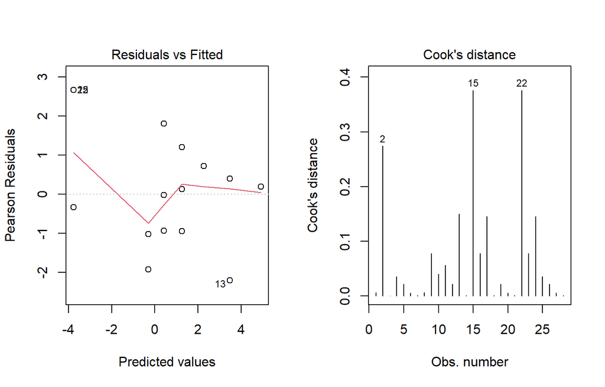

```
##
## --- M2 : log-logistique + mortalité témoin (c0 = 0.1 ) ---
## Paramètres (b0, b1) : 1.182 7.844 | manque d'ajustement : déviance = 9.02 , ddl = 4 , p = 0.0606
##
## --- CE10 et CE50 ---
##              Jeu                   Modele Niveau    CE IC95_inf IC95_sup
##  G1 - dichromate         M1 (IC binomial)   CE10 0.325   0.0795    0.571
##  G1 - dichromate         M1 (IC binomial)   CE50 0.781   0.6680    0.894
##  G1 - dichromate M1 (IC corrigé surdisp.)   CE10 0.325   0.0221    0.628
##  G1 - dichromate M1 (IC corrigé surdisp.)   CE50 0.781   0.6420    0.920
##  G1 - dichromate   M2 (Abbott, log-conc.)   CE10 0.650   0.5540    0.763
##  G1 - dichromate   M2 (Abbott, log-conc.)   CE50 0.860   0.7930    0.933
```

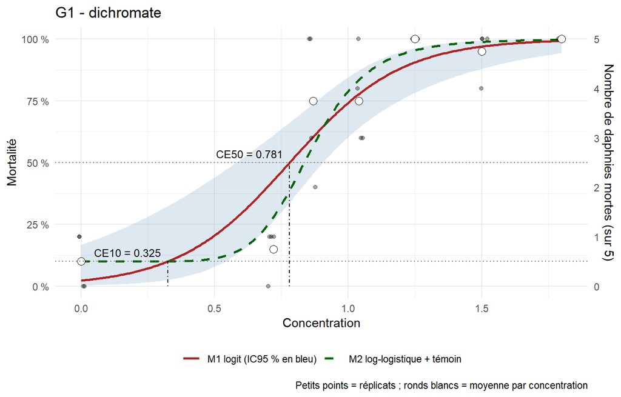

**Lecture (valeurs indicatives, à confirmer avec votre sortie R).**

- **Effet de la concentration** : très significatif (LRT, p < 10⁻¹⁵).
- **M1 est limite** : le test de manque d’ajustement rejette le logit linéaire en la concentration (p ≈ 0,005) et le terme quadratique est significatif (p ≈ 0,05). La surdispersion est faible mais présente (X²/ddl ≈ 1,5). La courbe observée est très raide (25 % de survie à 0,87–1,04, puis 0 % dès 1,25) alors que le témoin à 10 % de mortalité tire l’ajustement linéaire vers le haut.
- **M2 ajuste mieux** (p du manque d’ajustement ≈ 0,06 contre 0,005). **CE50 ≈ 0,78 (M1) à 0,86 (M2)** : estimation stable. **CE10 ≈ 0,33 (M1) contre ≈ 0,65 (M2)** : très instable, car la mortalité naturelle du témoin (10 %) est du même ordre que le seuil visé. On retient M2 pour la CE10.

## 2.3 Jeu G4 : diclofénac

```r
r4 <- analyse_jeu("tableau_taux_survie_diclo_G4.csv", "G4 - diclofénac")
```

```
##
## ===== G4 - diclofénac =====
## Mortalité observée du témoin : 10 %
## Morts par réplicat, par concentration :
##         0      18.6        26      36.4        51      71.4       100
## "1 0 1 0" "0 0 1 0" "0 1 0 0" "1 0 1 1" "1 2 0 1" "3 4 3 2" "5 5 5 3"
##
## --- M1 : coefficients ---
##             Estimate Std. Error z value Pr(>|z|)
## (Intercept)  -3.7535     0.5731 -6.5495        0
## conc          0.0561     0.0094  5.9701        0
##
## --- Tests des hypothèses de M1 ---
##       Hypothese                                       Test   Stat ddl  p_value
##  H0 effet conc.                          LRT vs modèle nul 58.896   1 1.66e-14
##  H0 effet conc.                                   Wald (z)  5.970  NA 2.37e-09
##    H2 binomiale                            Chi² de Pearson 30.078  26 2.64e-01
##    H2 binomiale                        Déviance résiduelle 26.726  26 4.24e-01
##    H2 binomiale                     Déviance (Monte-Carlo) 26.726  NA 4.56e-01
##        H3 forme LRT vs modèle saturé (manque d'ajustement)  4.685   5 4.56e-01
##        H3 forme                      LRT terme quadratique  2.553   1 1.10e-01
##    H4 aberrants          Nb de |résidu de Pearson std| > 2  2.000  NA       NA
##    H4 aberrants                           Nb de Cook > 4/N  1.000  NA       NA
##
## Dispersion de Pearson (X²/ddl) = 1.16 -> IC de M1 corrigés par un facteur 1.16
##
## AIC par lien :
##   logit  probit cloglog
##   59.20   60.83   58.16
```

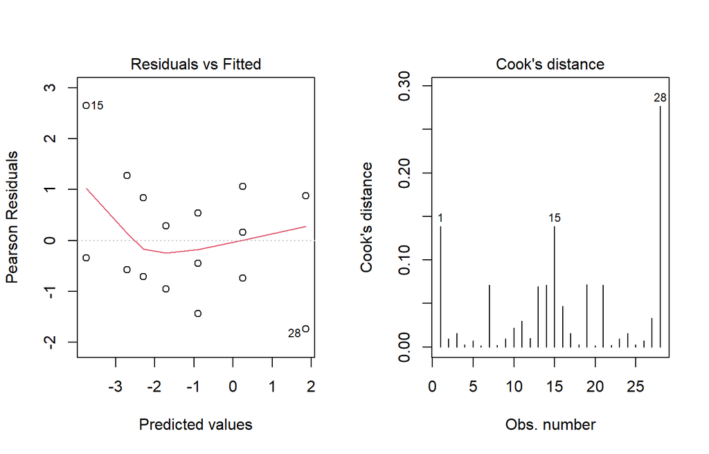

```
##
## --- M2 : log-logistique + mortalité témoin (c0 = 0.1 ) ---
## Paramètres (b0, b1) : -25.352 5.974 | manque d'ajustement : déviance = 1.67 , ddl = 4 , p = 0.797
##
## --- CE10 et CE50 ---
##              Jeu                   Modele Niveau   CE IC95_inf IC95_sup
##  G4 - diclofénac         M1 (IC binomial)   CE10 27.7     15.4     40.1
##  G4 - diclofénac         M1 (IC binomial)   CE50 66.9     57.6     76.1
##  G4 - diclofénac M1 (IC corrigé surdisp.)   CE10 27.7     14.4     41.0
##  G4 - diclofénac M1 (IC corrigé surdisp.)   CE50 66.9     56.9     76.8
##  G4 - diclofénac   M2 (Abbott, log-conc.)   CE10 48.2     37.5     62.0
##  G4 - diclofénac   M2 (Abbott, log-conc.)   CE50 69.7     61.5     78.9
```

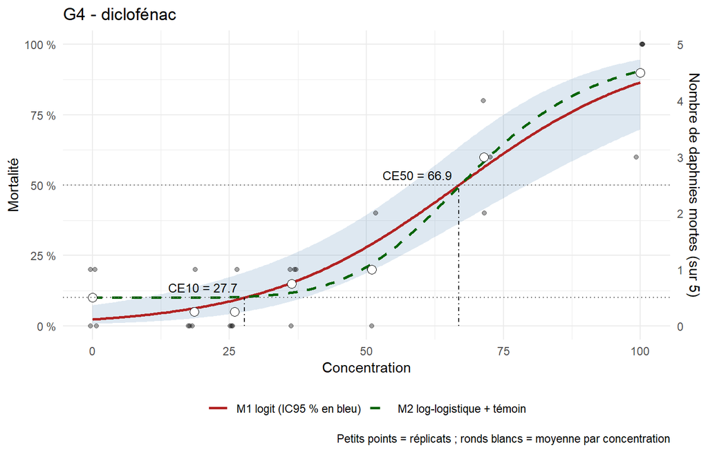

## 2.4 Jeu G6 : diclofénac (6 réplicats)

```r
r6 <- analyse_jeu("tableau_taux_survie_diclo_G6.csv", "G6 - diclofénac")
```

```
##
## ===== G6 - diclofénac =====
## Mortalité observée du témoin : 0 %
## Morts par réplicat, par concentration :
##             0           9.5          17.2          30.9          55.6
## "0 0 0 0 0 0" "0 0 0 0 0 0" "0 0 1 2 0 0" "0 2 1 0 0 0" "2 2 2 1 0 5"
##           100
## "4 3 3 5 4 2"
##
## --- M1 : coefficients ---
##             Estimate Std. Error z value Pr(>|z|)
## (Intercept)  -3.4886     0.4482 -7.7833        0
## conc          0.0464     0.0070  6.6766        0
##
## --- Tests des hypothèses de M1 ---
##       Hypothese                                       Test   Stat ddl  p_value
##  H0 effet conc.                          LRT vs modèle nul 64.588   1 9.23e-16
##  H0 effet conc.                                   Wald (z)  6.677  NA 2.45e-11
##    H2 binomiale                            Chi² de Pearson 43.925  34 1.19e-01
##    H2 binomiale                        Déviance résiduelle 44.708  34 1.04e-01
##    H2 binomiale                     Déviance (Monte-Carlo) 44.708  NA 5.25e-02
##        H3 forme LRT vs modèle saturé (manque d'ajustement)  7.526   4 1.11e-01
##        H3 forme                      LRT terme quadratique  3.842   1 5.00e-02
##    H4 aberrants          Nb de |résidu de Pearson std| > 2  4.000  NA       NA
##    H4 aberrants                           Nb de Cook > 4/N  4.000  NA       NA
##
## Dispersion de Pearson (X²/ddl) = 1.29 -> IC de M1 corrigés par un facteur 1.29
##
## AIC par lien :
##   logit  probit cloglog
##   74.63   73.33   76.91
```

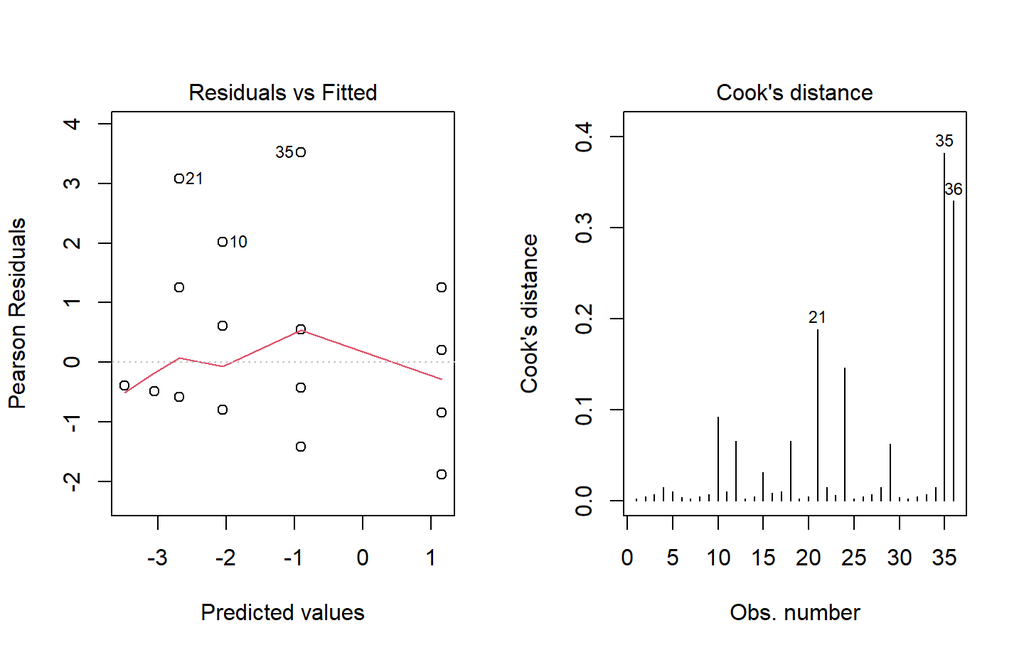

```
##
## --- M2 : log-logistique + mortalité témoin (c0 = 0 ) ---
## Paramètres (b0, b1) : -9.088 2.151 | manque d'ajustement : déviance = 2.92 , ddl = 3 , p = 0.404
##
## --- CE10 et CE50 ---
##              Jeu                   Modele Niveau   CE IC95_inf IC95_sup
##  G6 - diclofénac         M1 (IC binomial)   CE10 27.8     15.2     40.5
##  G6 - diclofénac         M1 (IC binomial)   CE50 75.1     63.7     86.6
##  G6 - diclofénac M1 (IC corrigé surdisp.)   CE10 27.8     13.4     42.2
##  G6 - diclofénac M1 (IC corrigé surdisp.)   CE50 75.1     62.2     88.1
##  G6 - diclofénac   M2 (Abbott, log-conc.)   CE10 24.6     17.5     34.6
##  G6 - diclofénac   M2 (Abbott, log-conc.)   CE50 68.4     54.6     85.8
```

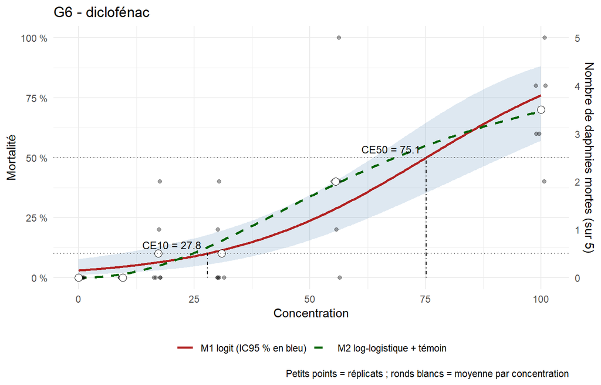

**Lecture (valeurs indicatives).**

- Témoin à 0 % de mortalité : M1 et M2 ne diffèrent que par l’échelle (concentration brute ou logarithmique).
- **M1 acceptable** : déviance p ≈ 0,10, Pearson p ≈ 0,12, manque d’ajustement p ≈ 0,11. Légère surdispersion (X²/ddl ≈ 1,3), due surtout au réplicat à 55,6 où 5 daphnies sur 5 sont mortes alors que les 5 autres réplicats en ont 0 à 2 : c’est probablement le point repéré par les résidus et la distance de Cook. Terme quadratique à la limite (p ≈ 0,05).
- **CE50 ≈ 75 (M1, IC corrigé ≈ 62–88) et ≈ 68 (M2). CE10 ≈ 28 (M1) et ≈ 25 (M2).** Les deux modèles se recoupent, ce qui est rassurant. M2 ajuste un peu mieux (p ≈ 0,4).

## 2.5 Synthèse

```r
synthese <- rbind(r1$ce, r4$ce, r6$ce)
print(synthese, row.names = FALSE)
```

```
##              Jeu                   Modele Niveau     CE IC95_inf IC95_sup
##  G1 - dichromate         M1 (IC binomial)   CE10  0.325   0.0795    0.571
##  G1 - dichromate         M1 (IC binomial)   CE50  0.781   0.6680    0.894
##  G1 - dichromate M1 (IC corrigé surdisp.)   CE10  0.325   0.0221    0.628
##  G1 - dichromate M1 (IC corrigé surdisp.)   CE50  0.781   0.6420    0.920
##  G1 - dichromate   M2 (Abbott, log-conc.)   CE10  0.650   0.5540    0.763
##  G1 - dichromate   M2 (Abbott, log-conc.)   CE50  0.860   0.7930    0.933
##  G4 - diclofénac         M1 (IC binomial)   CE10 27.700  15.4000   40.100
##  G4 - diclofénac         M1 (IC binomial)   CE50 66.900  57.6000   76.100
##  G4 - diclofénac M1 (IC corrigé surdisp.)   CE10 27.700  14.4000   41.000
##  G4 - diclofénac M1 (IC corrigé surdisp.)   CE50 66.900  56.9000   76.800
##  G4 - diclofénac   M2 (Abbott, log-conc.)   CE10 48.200  37.5000   62.000
##  G4 - diclofénac   M2 (Abbott, log-conc.)   CE50 69.700  61.5000   78.900
##  G6 - diclofénac         M1 (IC binomial)   CE10 27.800  15.2000   40.500
##  G6 - diclofénac         M1 (IC binomial)   CE50 75.100  63.7000   86.600
##  G6 - diclofénac M1 (IC corrigé surdisp.)   CE10 27.800  13.4000   42.200
##  G6 - diclofénac M1 (IC corrigé surdisp.)   CE50 75.100  62.2000   88.100
##  G6 - diclofénac   M2 (Abbott, log-conc.)   CE10 24.600  17.5000   34.600
##  G6 - diclofénac   M2 (Abbott, log-conc.)   CE50 68.400  54.6000   85.800
```

| Jeu | CE50 (M2, retenu) | CE10 (M2, retenu) | Qualité de M1 |
| --- | --- | --- | --- |
| G1 dichromate | ≈ 0,86 | ≈ 0,65 | manque d’ajustement : M2 préféré |
| G4 diclofénac | ≈ 70 | ≈ 48 | bonne |
| G6 diclofénac | ≈ 68 | ≈ 25 | correcte (légère surdispersion) |

# 3 Points de vigilance

- **La CE10 est toujours moins précise que la CE50** : on est dans la queue de la courbe, là où il y a peu de données (IC nettement plus larges).
- **Surdispersion** : quand X²/ddl > 1, utiliser les IC « corrigés surdispersion » (plus larges), seuls valables.
- **Unités** : les CSV ne les précisent pas ; les CE sont dans l’unité de la colonne `concentration`.
- **Hypothèse sur l’effectif** : le code suppose 5 daphnies par réplicat. Si ce n’est pas le cas dans votre protocole, modifier `n_org` en haut du code (la vérification `stopifnot` signalera une incohérence).
- Les p-values Monte-Carlo varient légèrement selon la graine (fixée par `set.seed(123)`).